# Exploratory Data Analysis of Attrition

Michael Olheiser

8/15/2020

## Introduction

video link: https://youtu.be/qj-pLmC59zE

Attrition is a key consideration for any successful company. It is strategic to identify components of a business that contribute to higher turnover rates in employees so the company can implement strategies to improve employee satisfaction. This report seeks to identify attributes of employees and their relation to the business that contribute to attrition. Specifically, we are interested in identifying the top three attributes that contribute to attrition, discovering trends in attrition per job, and predicting employee attrition using a classification algorithm.

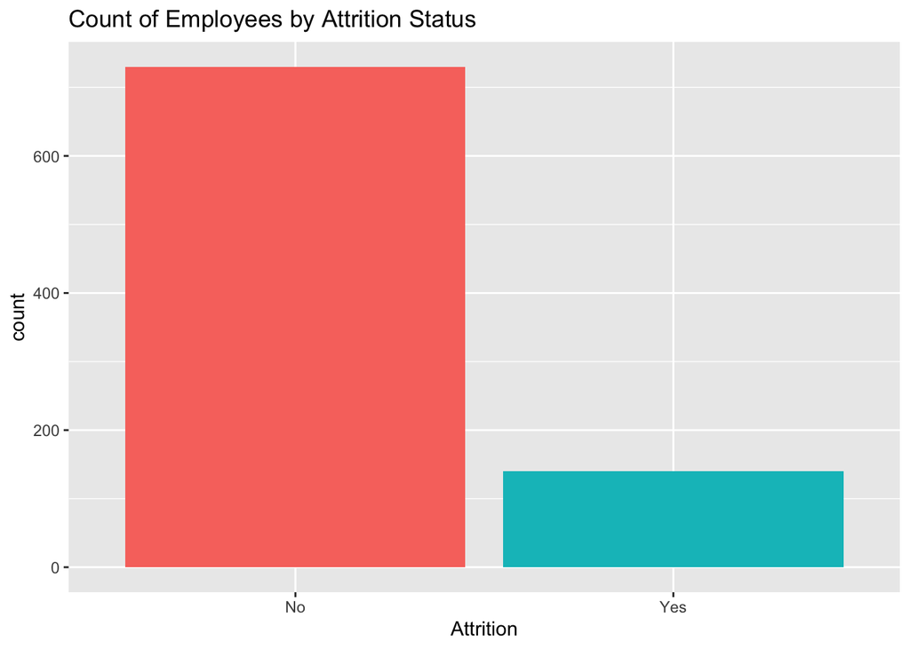

```r
data %>% ggplot(aes(x=Attrition, fill=Attrition)) +
  geom_bar() +
  ggtitle("Count of Employees by Attrition Status") +
  theme(legend.position = "none")
```

## Employee Survey Results

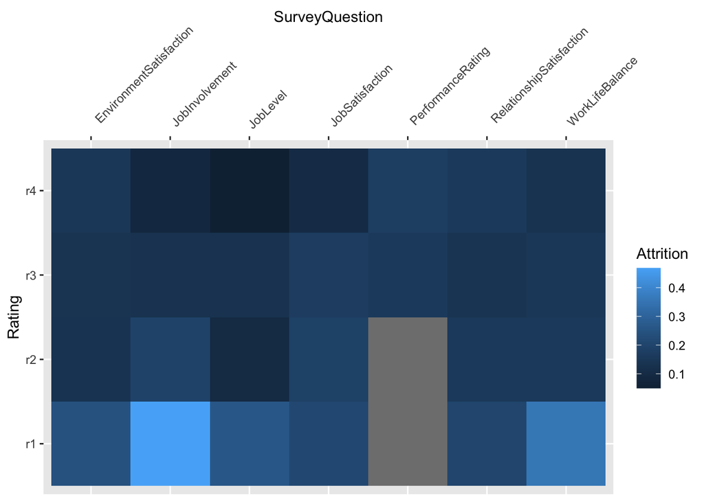

## Employee and Job Characteristics

Our dataset contains various characteristics of the employee such as Gender and Marital Status as well as specifics about the job itself such as Department, Travel Requirements and more. Due to the large number of attributes, we have shown attributes below that indicate a possible contributing to attrition. The bar charts below show the percentage of each category that left the company. There is some evidence here to suggest that Sales Departments are more likely to experience turnover especially those that are single, experience high travel and work over time.

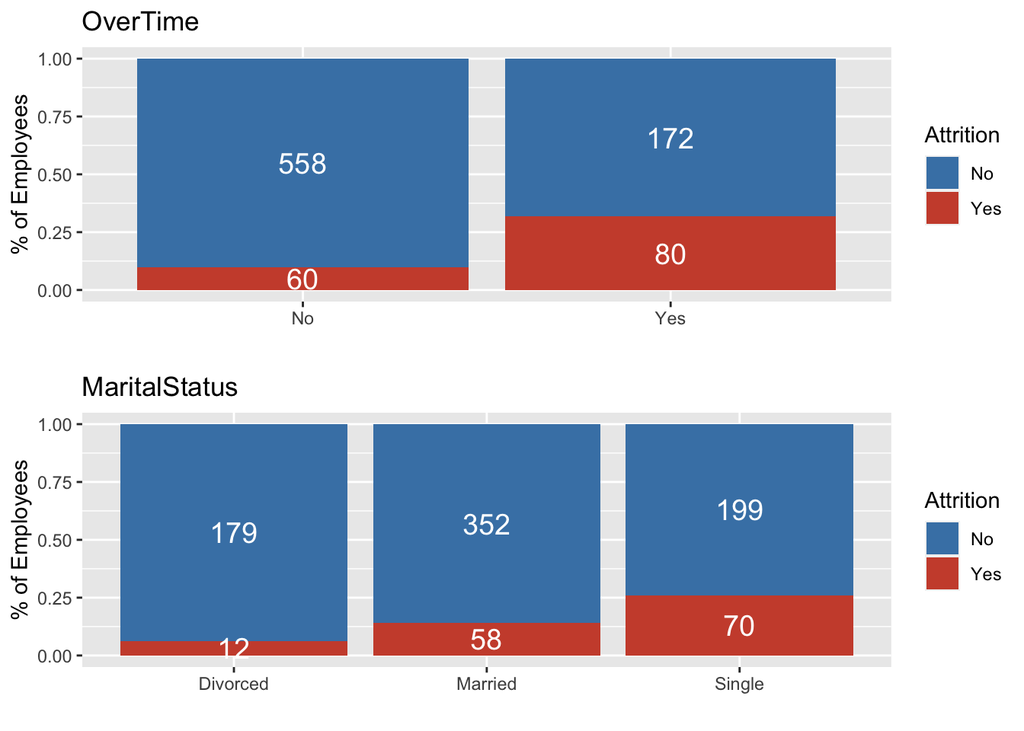

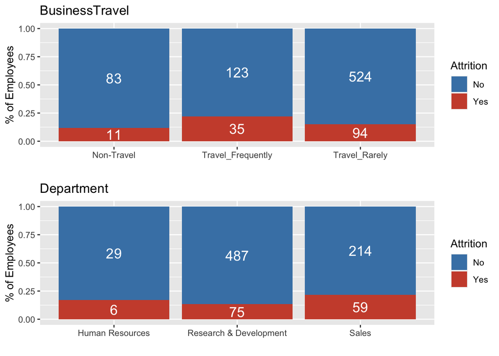

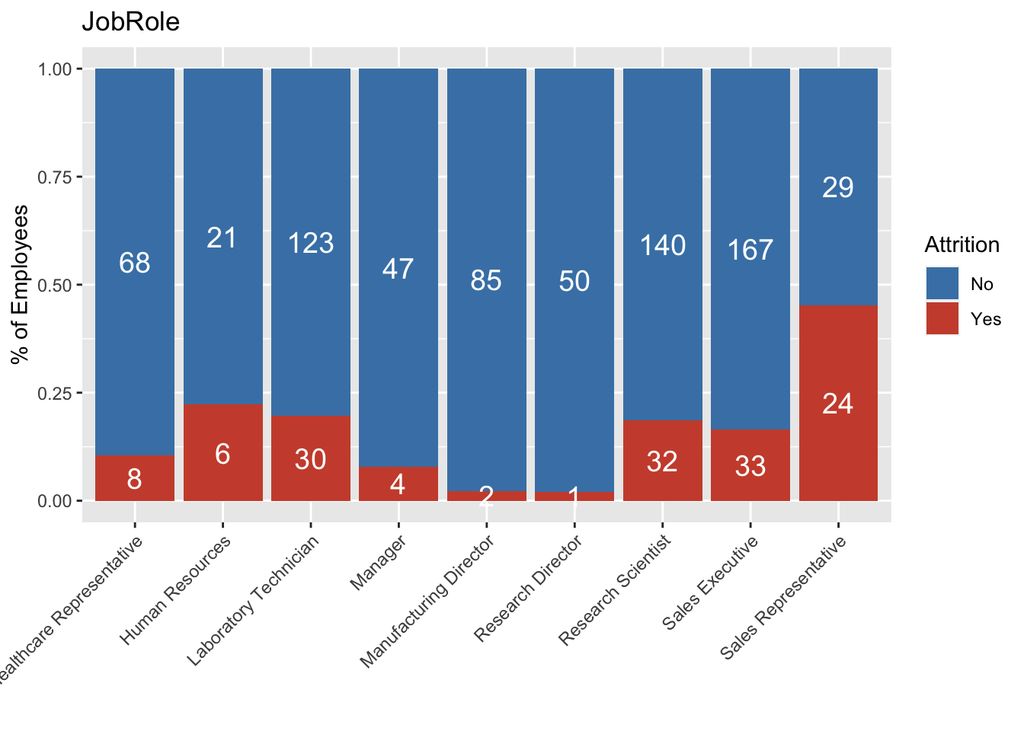

## Numerical Attributes of Attrition

This report has discussed various survey results and categorical attributes of employees and their job. In this section, we will uncover some trends in Attrition using numerical attributes such as monthly income, and age. Below we can see various box plots for each attribute grouped by Attrition in order to assess if there is any visual evidence that the attribute is associated with Attrition. In general those with lower incomes, lower age, less experience, and a longer commute are more likely to leave their company.

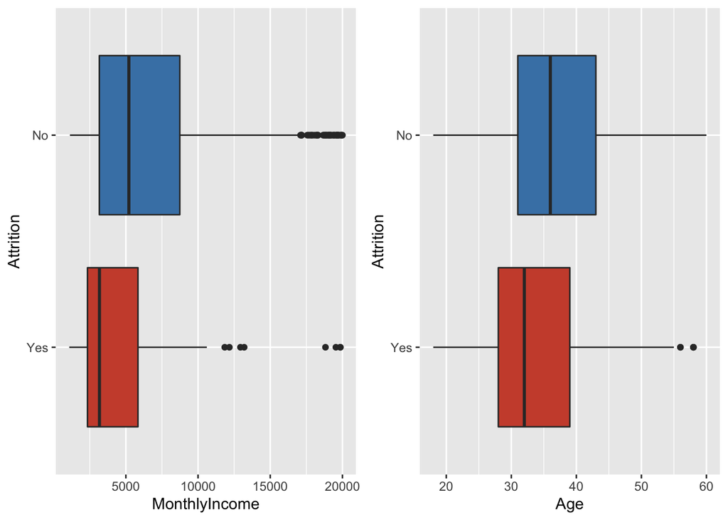

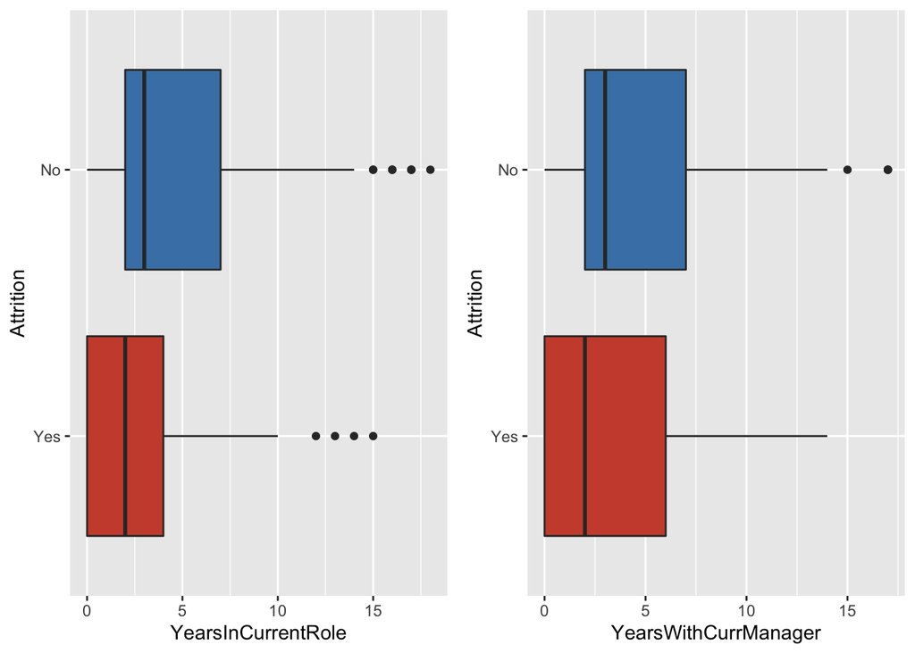

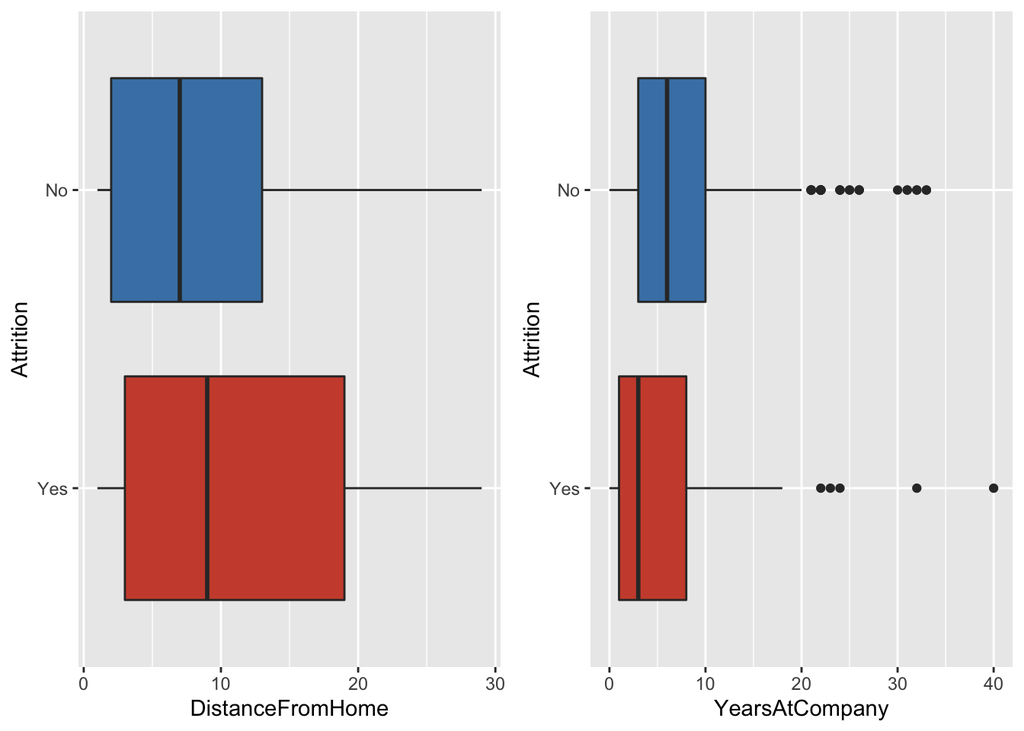

```r
# run t test on all numerical columns

numericals<-c("Age", "DailyRate", "DistanceFromHome", "HourlyRate", "MonthlyIncome",
            "MonthlyRate", "NumCompaniesWorked", "PercentSalaryHike",
              "TotalWorkingYears","TrainingTimesLastYear","YearsAtCompany", "YearsInCurrentRole",
              "YearsSinceLastPromotion","YearsWithCurrManager")

df_ttest<-data.frame(Attribute = numericals, pvalue = 0,  EffectSize = 0)
for (i in 1:length(numericals)) {
t<-t.test(data[,which(colnames(data)==numericals[i])]~data$Attrition)

df_ttest[i,2] = t$p.value
df_ttest[i,3] = abs(t$estimate[2] - t$estimate[1]) / t$stderr
}

library(kableExtra)
kable(df_ttest[order(df_ttest$pvalue),], caption = "T Test Results for Numerical Attributes") %>%  kable_styling()
```

T Test Results for Numerical Attributes

|  | Attribute | pvalue | EffectSize |
| --- | --- | --- | --- |
| 5 | MonthlyIncome | 0.0000002 | 5.3249407 |
| 9 | TotalWorkingYears | 0.0000007 | 5.1364157 |
| 12 | YearsInCurrentRole | 0.0000015 | 4.9512904 |
| 14 | YearsWithCurrManager | 0.0000051 | 4.6825717 |
| 1 | Age | 0.0000505 | 4.1508513 |
| 11 | YearsAtCompany | 0.0002563 | 3.7255881 |
| 3 | DistanceFromHome | 0.0164052 | 2.4217619 |
| 10 | TrainingTimesLastYear | 0.0594832 | 1.8953685 |
| 7 | NumCompaniesWorked | 0.0978823 | 1.6636811 |
| 6 | MonthlyRate | 0.1980950 | 1.2913212 |
| 4 | HourlyRate | 0.2744798 | 1.0958233 |
| 2 | DailyRate | 0.3188749 | 0.9993058 |
| 8 | PercentSalaryHike | 0.6692297 | 0.4278808 |
| 13 | YearsSinceLastPromotion | 0.8983165 | 0.1279615 |

```r
detach("package:kableExtra", unload=TRUE)
```

## Classifying Attrition with KNN

K Nearest Neighbors or KNN is a classification algorithm that will help us classify employees in terms of Attrition by the attributes we have analyzed so far. From our results above, we can now select some key attributes to achieve a more accurate classification model. Our model includes Monthly Incomes, Job Involvement, and Work Life Balance. Note that categorical variables are omitted from KNN due to the limitations of the algorithm. The table below displays the accuracy , Sensitivity and Specificity of the model.

```r
# Split data into test/train and build KNN

set.seed(1000)
iterations = 100
splitPerc = .70
trainIndices = sample(1:dim(data)[1],round(splitPerc * dim(data)[1]))
train = data[trainIndices,]
test = data[-trainIndices,]

data$logMonthlyIncome<-log(data$MonthlyIncome)

predictors<-c(which(colnames(data)=="MonthlyIncome"),
              which(colnames(data)=="WorkLifeBalance"),
             which(colnames(data)=="JobInvolvement")
)

# peform 100 iterations to find the best K value for KNN
accs = data.frame(accuracy = numeric(iterations), k = numeric(iterations))
for(i in 1:iterations)
{
    classifications = knn(train[,predictors],test[,predictors],train$Attrition, prob = TRUE, k = i)
    table(test$Attrition,classifications)
    CM = confusionMatrix(table(test$Attrition,classifications))
  accs$accuracy[i] = CM$overall[1]
  accs$k[i] = i
}

#plot(accs$k,accs$accuracy, type = "l", xlab = "k", ylab="Accuracy")

classifications = knn(train[,predictors],test[,predictors],train$Attrition, prob = TRUE, k = 7)

CM = confusionMatrix(table(test$Attrition,classifications))

knn_results<-data.frame(Model="KNN for Attrition",
           Accuracy=CM$overall[1],
           Sensitivity=CM$byClass[1],
           Specificity=CM$byClass[2])

library(kableExtra)
kable(table(test$Attrition,classifications),caption="Confusion Matrix for Classifying Attrition (Columns are Predictions)") %>% kable_styling()
```

Confusion Matrix for Classifying Attrition (Columns are Predictions)

|  | No | Yes |
| --- | --- | --- |
| No | 218 | 3 |
| Yes | 37 | 3 |

```r
kable(knn_results) %>% kable_styling()
```

|  | Model | Accuracy | Sensitivity | Specificity |
| --- | --- | --- | --- | --- |
| Accuracy | KNN for Attrition | 0.8467433 | 0.854902 | 0.5 |

```r
# predict attrition
# test_noAttrition<-read.csv("/Users/molheiser/Downloads/CaseStudy2CompSet_No_Attrition.csv")
#
# predictors_noAtt<-c(which(colnames(test_noAttrition)=="MonthlyIncome"),
#               which(colnames(test_noAttrition)=="JobInvolvement"),
#               which(colnames(test_noAttrition)=="WorkLifeBalance")
# )
# classifications_noAttrition = knn(data[,predictors],test_noAttrition[,predictors_noAtt], data$Attrition, k = 7)
#
# predicted_Attrition<-data.frame("ID" = test_noAttrition$ID, "Attrition"= classifications_noAttrition )
# write.csv(predicted_Attrition, "Case2PredictionsOlheiser Attrition.csv")
```

## Linear Regression for Monthly Salaries

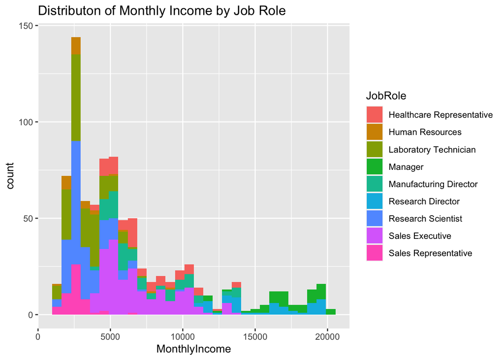

```r
data%>% ggplot(aes(x=MonthlyIncome, fill=JobRole)) +
  geom_histogram() +
  ggtitle("Distributon of Monthly Income by Job Role")
```

```r
model<-lm(MonthlyIncome~TotalWorkingYears + YearsAtCompany + JobRole + JobLevel , data=data)
#summary(model)
# calculate RMSE
res<-summary(model)
RSS <- c(crossprod(res$residuals))
MSE <- RSS / length(res$residuals)
summary(model)
```

```
##
## Call:
## lm(formula = MonthlyIncome ~ TotalWorkingYears + YearsAtCompany +
##     JobRole + JobLevel, data = data)
##
## Residuals:
##     Min      1Q  Median      3Q     Max
## -3943.0  -639.9   -18.4   607.4  4128.9
##
## Coefficients:
##                               Estimate Std. Error t value Pr(>|t|)
## (Intercept)                   -104.966    203.362  -0.516 0.605881
## TotalWorkingYears               50.661      8.770   5.777 1.07e-08 ***
## YearsAtCompany                  -5.662      7.860  -0.720 0.471477
## JobRoleHuman Resources        -317.732    251.883  -1.261 0.207497
## JobRoleLaboratory Technician  -593.911    169.098  -3.512 0.000468 ***
## JobRoleManager                3990.839    229.324  17.403  < 2e-16 ***
## JobRoleManufacturing Director  136.179    167.266   0.814 0.415787
## JobRoleResearch Director      3974.536    216.041  18.397  < 2e-16 ***
## JobRoleResearch Scientist     -321.494    169.487  -1.897 0.058181 .
## JobRoleSales Executive         -65.059    144.267  -0.451 0.652134
## JobRoleSales Representative   -410.074    211.720  -1.937 0.053089 .
## JobLevel                      2801.241     82.217  34.071  < 2e-16 ***
## ---
## Signif. codes:  0 '***' 0.001 '**' 0.01 '*' 0.05 '.' 0.1 ' ' 1
##
## Residual standard error: 1063 on 858 degrees of freedom
## Multiple R-squared:  0.9472, Adjusted R-squared:  0.9465
## F-statistic:  1400 on 11 and 858 DF,  p-value: < 2.2e-16
```

```r
sqrt(MSE)
```

```
## [1] 1055.698
```

```r
# predict salaries
# test_noSalary<-read.csv("/Users/molheiser/Downloads/CaseStudy2CompSet_No_Salary.csv")
# pred<-predict(model, newdata=test_noSalary)
# predictedSalary<-data.frame("ID" = test_noSalary$ID, "MonthlyIncome" = pred)
# write.csv(predictedSalary, "Case2PredictionsOlheiser Salary.csv")
```

## Conclusions

We explored various attributes of employees, their job, and survey responses to determine key factors contributing to Attrition. We discovered that employees ranking Work Life Balance and Job Involvement low are more likely to leave the company. Furthermore, employees that are Sales Representatives appear to experience higher turnover than other job roles possibly due to the amount of travel required. It’s important to note that none of these factors necessarily cause Attrition but are associated with Attrition.